**Autor** : Jobenil Luiz Magalhães Júnior

**e-mail**: profjobenil@yahoo.com.br

# Sumário

- Sumário
- Título
- Introdução
- Teoria da Resposta ao Item
- Questionário Socioeconômico
- Leitura e Preparação do arquivo
- Análise Descritiva e Confirmatória dos dados
- Resultados e Discussões
- Conclusão
- Referências bibliográticas consultadas

# Título

voltar ao sumário

Importância das áreas de conhecimento - Matemática e suas Tecnologias; Linguagens, Códigos e suas Tecnologias; Ciências da Natureza e suas Tecnologias; e Ciências Humanas e suas Tecnologias na composição da proficiência dos candidatos ao ENEM 2021 em Goiás

# Introdução

voltar ao sumário

Históricamente o Brasil vêm realizando através do INEP - Instituto Nacional de Estudos e Pesquisas Educacionais Anísio Teixeira uma série de provas de âmbito nacional como o **SAEB** e **Prova Brasil** com vistas a avaliação do Sistema Nacional de Ensino Básico e Fundamental. Tais avaliações tem por objetivo mensurar a qualidade do ensino efetuado pelos diferentes entes federativos, quer no âmbito público quanto no âmbito privado. Pretende-se que tais avaliações prossibilitem aos **administradores** das diferentes redes de ensino reflitam e redirecionem **ações** no sentido de efetuar melhorias em seus respectivos níveis de responsabilidade. O **ENEM** - Exame Nacional do Ensino Médio, é uma prova realizada pelo Ministério da Educação desde 1998 com objetivo de avaliar a qualidade do ensino médio praticado no Brasil e que a partir de 2009 amplia o escopo visando a seleção de candidatos às universidades federais do país. Desde sua criação emprega na elaboração das notas dos candidatos uma metodologia denominada TRI - Teoria da Resposta ao Item. A referida teoria pretende aferir a partir da análise sistemática de cada questão da prova, um nível denominado nível de proficiência do candidato. O presente trabalho pretende levantar como e o quanto as diferentes áreas do conhecimento afetam o resultado final do aluno e verificar quais fatores socioeconômicos influênciam esses resultados. Para esse fim selecionaremos os dados referentes aos candidatos no estado de Goiás para o exame realizado em 2021.

# 1. Teoria da Resposta ao Item

voltar ao sumário

A Teoria da Resposta ao Item foi inicialmente proposta entre 1950 e 1960 por três pesquisadores independentes [Frederic M. Lord](https://en.wikipedia.org/wiki/Frederic_M._Lord), [Georg Rach](https://en.wikipedia.org/wiki/Georg_Rasch) e [Paul Lazarsfeld](https://en.wikipedia.org/wiki/Paul_Lazarsfeld) e tinha por objetivos superar algumas dificuldades de interpretação dos resultados dos testes de proficiência. De uma maneira geral, podemos dizer que os testes de proficiência acadêmica, sobretudo os testes de **"lápis e papel"** possuem mais características **subjetivas** do que **objetivas** pois procuram medir algum tipo de proficiência cognitiva chamadas de **traços latentes**. No presente caso, o ENEM procura medir as proficiências em Matemática e suas Tecnologias; Linguagens, Códigos e suas Tecnologias; Ciências da Natureza e suas Tecnologias; e Ciências Humanas e suas Tecnologias. A métodologia tradicionalmente utilizada em avaliações de ensino e educação é chamada de TCL - Teoria Clássica dos Testes a qual considera o número total de acertos em um teste como base para concepção de suas validações, desconsiderando **peculiaridades** inerentes a cada uma das suas questões, sendo que essencialmente os **traços latentes** apresentam-se mais como numa escala **ordinal** do que numa escala de **razão** o que "teóricamente" invalidaria as conclusões para as quais os citados testes serviriam. Na TRI ficam estabelecidos a identificação das características - **discriminação, dificuldade e aleatoriedade** para cada **item** da prova, o que permite calcular suas probabilidades de acertos dado um certo nível de proficiência do respondente sendo essa última uma característica **"imanente"** do mesmo e portanto indicador **"inequivoco"** da habilidade. É com base nessas características que diversas instituições como o College Board que aplica o SAT Schollastic Aptitude Test utilizado pelos jovens americanos acessarem o ensino superior, a OCDE para execução do PISA e o INEP para execução de suas avaliações educacionais.

No caso do ENEM cada uma das questões é préviamente calibrada através da aplicação das mesmas a uma população de alunos do ensino médio selecionados aleatóriamente nas diversas escolas do país. Posteriormente é calculada função característica do item conforme a função descrita abaixo:$$p_i(\theta)= c_i + \frac{1-c_i}{1 + e^{-a_i(\theta - b_i}}$$

onde,

- $a_i$ é o índice de discriminação do item i
- $b_i$ é o índice de dificuldade do item i
- $c_i$ é um fator de aleatóriedade do item i, considerando a possibilidade de um aluno acertar no chute.

$\theta$ indica o nível de proficiência do aluno, que no caso do ENEM tem média 500 e desvio padrão 100 considerando uma escala na distribuição normal.

As questões assim calibradas são colocadas em um banco chamado de Banco de Questões as quais serão selecionadas para compor a prova do ENEM.

A figura abaixo apresenta a curva característica de um item segundo a TRI.

[figure not shown]

Observamos todos os citados parâmetros a, b, c e $\theta$ representado aqui como os níveis de proficiência em uma escala que vai de $-\infty$ a $\infty$. No caso da proficiência estabelecida no ENEM uma escala normalizada com média 500 e desvio padrão 100.

# Questionário Socioeconômico

voltar ao sumário

Os candidatos ao ENEM também são submetidos ao preenchimento de um questionário que permite confirmar algumas alegações legais a que tem direito como indicação de raça e tipo de escola realizou o ensino médio - para conceção de quotas. O questionário também levanta informações sobre formação dos pais e econômicas como itens possuem em suas casas.

Cerca de 25 questões que levantam informações de natureza econômica, serão utilizadas para a composição da categorização de níveis de renda econômica segundo o **Critério Brasil**, metodologia idealizada pelo ABEP - Associação Brasileira de Empresas de Pesquisa que identifica 6 extratos socioeconômicos. Estes serão utilizados neste trabalho para estabelecimento de comparações de forma a estabelecer relações das mesmas com os resultados das diferentes áreas de avaliação da prova.

# Leitura e Preparação do arquivo

voltar ao sumário

Para efeito deste trabalho empregaremos os microdados disponibilizados pelo [MEC](https://www.gov.br/inep/pt-br/acesso-a-informacao/dados-abertos/microdados/enem) referentes à prova realizada em 2021. Dentre os arquivos encontram-se dois, um contendo os dados coletados para cada item das provas e outro contendo os dados coletados com as respostas dos candidatos. Empregaremos exclusivamente os dados deste último. Circunscriveremos a abrangência das análises para os dados referentes aos candidatos que realizaram a prova no estado de Goiás, estado que resido. Para leitura e análises dos dados empregaremos os recursos disponíveis na linguagem [Python](https://www.python.org/). Nos inspiramos no trabalho apresentado por [Viviane Maranhão](https://www.linkedin.com/in/vivianemaranhao/) durante o Meetup indicado no vídeo abaixo.

```python
from IPython.display import HTML
HTML('<iframe width="560" height="315" src="https://www.youtube.com/embed/PaYneq1PFYo" title="YouTube video player" frameborder="0" allow="accelerometer; autoplay; clipboard-write; encrypted-media; gyroscope; picture-in-picture" allowfullscreen></iframe>')
```

[video not shown]

Nosso primeiro passo foi selecionar algumas variáveis do questionário socioeconômico empregando a biblioteca pandas. Do Censo Escolar selecionamos para essa análise as seguintes variáveis:

- TP_FAIXA_ETARIA
- TP_SEXO
- TP_COR_RACA
- TP_ESTADO_CIVIL
- SG_UF_ESC
- TP_DEPENDENCIA_ADM_ESC

Do resultado da prova as notas obtidas pelos candidatos:

- NU_NOTA_CN
- NU_NOTA_CH
- NU_NOTA_LC
- NU_NOTA_MT
- TP_STATUS_REDACAO
- NU_NOTA_REDACAO

E do questionário socioeconômico as questões de 1 a 25. Uma nova variável foi obtida através obtenção da média das notas das 5 diferentes áreas sendo denominada de NOTA_FINAL.

```python
import pandas as pd
import numpy as np

base_original = "./DADOS/MICRODADOS_ENEM_2021.csv"
base_filtrada = "./DADOS/MICRODADOS_ENEM_2021_FILTRADO.csv"
dados_final = pd.DataFrame()

for data in pd.read_csv(base_original, encoding='ISO-8859-1',sep=';', chunksize=100000,
                        usecols = ['TP_FAIXA_ETARIA', 'TP_SEXO', 'TP_COR_RACA', 'TP_ESTADO_CIVIL', 'SG_UF_ESC',
                                   'NU_NOTA_CN', 'NU_NOTA_CH', 'NU_NOTA_LC', 'NU_NOTA_MT', 'TP_DEPENDENCIA_ADM_ESC', 'NU_NOTA_REDACAO',
                                   'Q001', 'Q002', 'Q003', 'Q004', 'Q005', 'Q006', 'Q007', 'Q008', 'Q009',
                                   'Q010', 'Q011', 'Q012', 'Q013', 'Q014', 'Q015', 'Q016',
                                   'Q017', 'Q018', 'Q019', 'Q020', 'Q021', 'Q022', 'Q023',
                                   'Q024', 'Q025']):
    data = data.query('SG_UF_ESC == "GO" and NU_NOTA_CN>0 and NU_NOTA_CH>0 and NU_NOTA_LC>0 and NU_NOTA_MT>0')
    data = data.dropna()
    dados_final = pd.concat([dados_final, data])

notas = ['NU_NOTA_CN', 'NU_NOTA_CH', 'NU_NOTA_LC', 'NU_NOTA_MT', 'NU_NOTA_REDACAO']
dados_final['NOTA_FINAL'] = dados_final[notas].sum(axis=1) / 5
dados_final.drop('SG_UF_ESC', axis=1, inplace=True)
dados_final.head().T
```

|  | 146 | 214 | 232 | 243 | 305 |
| --- | --- | --- | --- | --- | --- |
| TP_FAIXA_ETARIA | 3 | 3 | 3 | 3 | 2 |
| TP_SEXO | F | M | F | F | F |
| TP_ESTADO_CIVIL | 1 | 1 | 1 | 1 | 1 |
| TP_COR_RACA | 3 | 1 | 3 | 1 | 1 |
| TP_DEPENDENCIA_ADM_ESC | 4.0 | 2.0 | 2.0 | 2.0 | 2.0 |
| NU_NOTA_CN | 458.5 | 606.8 | 482.3 | 433.6 | 522.4 |
| NU_NOTA_CH | 477.4 | 661.9 | 572.4 | 382.0 | 555.2 |
| NU_NOTA_LC | 393.1 | 618.3 | 541.4 | 503.9 | 492.0 |
| NU_NOTA_MT | 482.9 | 694.3 | 479.9 | 516.3 | 434.4 |
| NU_NOTA_REDACAO | 460.0 | 740.0 | 560.0 | 680.0 | 600.0 |
| Q001 | H | F | E | E | H |
| Q002 | B | G | B | E | H |
| Q003 | F | B | D | C | B |
| Q004 | B | D | D | B | B |
| Q005 | 5.0 | 4.0 | 4.0 | 5.0 | 3.0 |
| Q006 | D | F | D | C | B |
| Q007 | A | A | A | A | A |
| Q008 | C | C | C | B | B |
| Q009 | D | D | C | C | C |
| Q010 | A | B | B | A | A |
| Q011 | B | A | A | A | B |
| Q012 | B | B | C | B | B |
| Q013 | B | A | B | A | A |
| Q014 | B | B | B | A | B |
| Q015 | A | A | A | A | A |
| Q016 | B | B | B | A | B |
| Q017 | A | A | A | A | A |
| Q018 | A | B | A | A | A |
| Q019 | B | B | C | A | B |
| Q020 | A | A | A | A | A |
| Q021 | A | A | A | A | A |
| Q022 | E | D | E | B | A |
| Q023 | A | A | A | A | A |
| Q024 | B | B | B | A | A |
| Q025 | B | B | B | B | B |
| NOTA_FINAL | 454.38 | 664.26 | 527.2 | 503.16 | 520.8 |

```python
dados_final.shape
```

```
(24482, 36)
```

Obtendo-se assim uma amostra contendo 24.482 respostas e 36 variáveis.

Realizamos também a conversão de tipos de algumas das variáveis a fim possibilitar sua utilização nas análises que se seguirão.

```python
dados_final.TP_FAIXA_ETARIA = dados_final.TP_FAIXA_ETARIA.astype(int)
dados_final.TP_SEXO = dados_final.TP_SEXO.astype('category')
dados_final.TP_COR_RACA = dados_final.TP_COR_RACA.astype(int)
dados_final.TP_ESTADO_CIVIL = dados_final.TP_ESTADO_CIVIL.astype(int)
dados_final.TP_DEPENDENCIA_ADM_ESC = dados_final.TP_DEPENDENCIA_ADM_ESC.astype(int)
dados_final.Q006 = pd.Categorical(dados_final.Q006)
dados_final['Q006'] = dados_final.Q006.cat.codes

dados_final.Q007 = pd.Categorical(dados_final.Q007)
dados_final['Q007'] = dados_final.Q007.cat.codes

dados_final.Q008 = pd.Categorical(dados_final.Q008)
dados_final['Q008'] = dados_final.Q008.cat.codes

dados_final.Q009 = pd.Categorical(dados_final.Q009)
dados_final['Q009'] = dados_final.Q009.cat.codes

dados_final.Q010 = pd.Categorical(dados_final.Q010)
dados_final['Q010'] = dados_final.Q010.cat.codes

dados_final.Q011 = pd.Categorical(dados_final.Q011)
dados_final['Q011'] = dados_final.Q011.cat.codes

dados_final.Q012 = pd.Categorical(dados_final.Q012)
dados_final['Q012'] = dados_final.Q012.cat.codes

dados_final.Q013 = pd.Categorical(dados_final.Q013)
dados_final['Q013'] = dados_final.Q013.cat.codes

dados_final.Q014 = pd.Categorical(dados_final.Q014)
dados_final['Q014'] = dados_final.Q014.cat.codes

dados_final.Q015 = pd.Categorical(dados_final.Q015)
dados_final['Q015'] = dados_final.Q015.cat.codes

dados_final.Q016 = pd.Categorical(dados_final.Q016)
dados_final['Q016'] = dados_final.Q016.cat.codes

dados_final.Q017 = pd.Categorical(dados_final.Q017)
dados_final['Q017'] = dados_final.Q017.cat.codes

dados_final.Q018 = pd.Categorical(dados_final.Q018)
dados_final['Q018'] = dados_final.Q018.cat.codes

dados_final.Q019 = pd.Categorical(dados_final.Q019)
dados_final['Q019'] = dados_final.Q019.cat.codes

dados_final.Q020 = pd.Categorical(dados_final.Q020)
dados_final['Q020'] = dados_final.Q020.cat.codes

dados_final.Q021 = pd.Categorical(dados_final.Q021)
dados_final['Q021'] = dados_final.Q021.cat.codes

dados_final.Q022 = pd.Categorical(dados_final.Q022)
dados_final['Q022'] = dados_final.Q022.cat.codes

dados_final.Q023 = pd.Categorical(dados_final.Q023)
dados_final['Q023'] = dados_final.Q023.cat.codes

dados_final.Q024 = pd.Categorical(dados_final.Q024)
dados_final['Q024'] = dados_final.Q024.cat.codes

dados_final.Q025 = pd.Categorical(dados_final.Q025)
dados_final['Q025'] = dados_final.Q025.cat.codes

dados_final.head()
```

|  | TP_FAIXA_ETARIA | TP_SEXO | TP_ESTADO_CIVIL | TP_COR_RACA | TP_DEPENDENCIA_ADM_ESC | NU_NOTA_CN | NU_NOTA_CH | NU_NOTA_LC | NU_NOTA_MT | NU_NOTA_REDACAO | ... | Q017 | Q018 | Q019 | Q020 | Q021 | Q022 | Q023 | Q024 | Q025 | NOTA_FINAL |
| --- | --- | --- | --- | --- | --- | --- | --- | --- | --- | --- | --- | --- | --- | --- | --- | --- | --- | --- | --- | --- | --- |
| 146 | 3 | F | 1 | 3 | 4 | 458.5 | 477.4 | 393.1 | 482.9 | 460.0 | ... | 0 | 0 | 1 | 0 | 0 | 4 | 0 | 1 | 1 | 454.38 |
| 214 | 3 | M | 1 | 1 | 2 | 606.8 | 661.9 | 618.3 | 694.3 | 740.0 | ... | 0 | 1 | 1 | 0 | 0 | 3 | 0 | 1 | 1 | 664.26 |
| 232 | 3 | F | 1 | 3 | 2 | 482.3 | 572.4 | 541.4 | 479.9 | 560.0 | ... | 0 | 0 | 2 | 0 | 0 | 4 | 0 | 1 | 1 | 527.20 |
| 243 | 3 | F | 1 | 1 | 2 | 433.6 | 382.0 | 503.9 | 516.3 | 680.0 | ... | 0 | 0 | 0 | 0 | 0 | 1 | 0 | 0 | 1 | 503.16 |
| 305 | 2 | F | 1 | 1 | 2 | 522.4 | 555.2 | 492.0 | 434.4 | 600.0 | ... | 0 | 0 | 1 | 0 | 0 | 0 | 0 | 0 | 1 | 520.80 |

5 rows × 36 columns

As questões do questionário socioeconômico serão transformadas segundo o Critério Brasil nas categorias de classes econômicas utilizadas pela ABEP. Apresentamos um resumo das categorias e respectivas pontuações nas duas imagens abaixo.

[figure not shown]

Portanto, antes da categorização final, será necessário a transformação das correspondentes questões socioeconômicas correspondentes nas respectivas pontuações indicadas nas tabelas acima.

[figure not shown]

```python
valores = {'Q001':{'A':0, 'B':0, 'C': 1, 'D': 2, 'E': 4, 'F': 7, 'G': 7, 'H':-1},
          'Q002':{'A':0, 'B':0, 'C': 1, 'D': 2, 'E': 4, 'F': 7, 'G': 7, 'H':-1}}

dados_final.replace(valores, inplace=True)
marca = dados_final.eval('Q001 >= Q002')

dados_final = dados_final.assign(Q001_temp = np.where(marca==True, dados_final['Q001'], dados_final['Q002']))

dados_final.replace({'Q001_temp':{-1:None}}, inplace=True)

dados_final.dropna()

dados_final['Q007'] = pd.cut(x = dados_final['Q007'], right=False, bins = [0, 1, 2, 3, 4, 5], labels = [0, 3, 7, 10, 13])
dados_final['Q008'] = pd.cut(x = dados_final['Q008'], right=False, bins = [0, 1, 2, 3, 4, 5], labels = [0, 3, 7, 10, 14])
dados_final['Q010'] = pd.cut(x = dados_final['Q010'], right=False, bins = [0, 1, 2, 3, 4, 5], labels = [0, 3, 5, 8, 11])
dados_final['Q011'] = pd.cut(x = dados_final['Q011'], right=False, bins = [0, 1, 2, 5], labels = [0, 1, 3])
dados_final['Q012'] = pd.cut(x = dados_final['Q012'], right=False, bins = [0, 1, 2, 3, 5], labels = [0, 2, 3, 5])
dados_final['Q013'] = pd.cut(x = dados_final['Q013'], right=False, bins = [0, 1, 2, 3, 5], labels = [0, 2, 4, 6])
dados_final['Q014'] = pd.cut(x = dados_final['Q014'], right=False, bins = [0, 1, 2, 3, 5], labels = [0, 2, 4, 6])
dados_final['Q015'] = pd.cut(x = dados_final['Q015'], right=False, bins = [0, 1, 5], labels = [0, 2])
dados_final['Q016'] = pd.cut(x = dados_final['Q016'], right=False, bins = [0, 1, 2, 5], labels = [0, 2, 4])
dados_final['Q017'] = pd.cut(x = dados_final['Q017'], right=False, bins = [0, 1, 4, 5], labels = [0, 3, 6])
dados_final['Q018'] = pd.cut(x = dados_final['Q018'], right=False, bins = [0, 1, 5], labels = [0, 2])
dados_final['Q020'] = pd.cut(x = dados_final['Q020'], right=False, bins = [0, 1, 2, 3, 4, 5], labels = [0, 1, 3, 4, 6])
dados_final['Q021'] = pd.cut(x = dados_final['Q021'], right=False, bins = [0, 1, 5], labels = [0, 2])
dados_final['Q024'] = pd.cut(x = dados_final['Q024'], right=False, bins = [0, 1, 2, 3, 4, 5], labels = [0, 3, 6, 8, 11])
dados_final['Q025'] = pd.cut(x = dados_final['Q025'], right=False, bins = [0, 1, 5], labels = [0, 2])

dados_final['PONTUACAO'] = dados_final[['Q001_temp', 'Q007', 'Q008', 'Q010', 'Q011', 'Q012', 'Q013', 'Q014',
                                        'Q015', 'Q016', 'Q017', 'Q018', 'Q020', 'Q021', 'Q024', 'Q025']].sum(axis=1)
dados_final['PONTUACAO'] = pd.cut(x = dados_final['PONTUACAO'], right=False, bins = [0, 17, 23, 29, 38, 45, 100], labels = [0, 1, 2, 3, 4, 5])

dados_final = dados_final.drop(columns=['Q001_temp','Q001', 'Q002', 'Q003', 'Q004', 'Q005', 'Q006', 'Q007', 'Q008', 'Q009', 'Q010', 'Q011', 'Q012', 'Q013',
                                'Q014', 'Q015', 'Q016', 'Q017', 'Q018', 'Q019', 'Q020', 'Q021', 'Q022', 'Q023', 'Q024', 'Q025'])

dados_final.to_csv(base_filtrada, index=False)
dados_final.head().T
```

|  | 146 | 214 | 232 | 243 | 305 |
| --- | --- | --- | --- | --- | --- |
| TP_FAIXA_ETARIA | 3 | 3 | 3 | 3 | 2 |
| TP_SEXO | F | M | F | F | F |
| TP_ESTADO_CIVIL | 1 | 1 | 1 | 1 | 1 |
| TP_COR_RACA | 3 | 1 | 3 | 1 | 1 |
| TP_DEPENDENCIA_ADM_ESC | 4 | 2 | 2 | 2 | 2 |
| NU_NOTA_CN | 458.5 | 606.8 | 482.3 | 433.6 | 522.4 |
| NU_NOTA_CH | 477.4 | 661.9 | 572.4 | 382.0 | 555.2 |
| NU_NOTA_LC | 393.1 | 618.3 | 541.4 | 503.9 | 492.0 |
| NU_NOTA_MT | 482.9 | 694.3 | 479.9 | 516.3 | 434.4 |
| NU_NOTA_REDACAO | 460.0 | 740.0 | 560.0 | 680.0 | 600.0 |
| NOTA_FINAL | 454.38 | 664.26 | 527.2 | 503.16 | 520.8 |
| PONTUACAO | 1 | 3 | 2 | 0 | 0 |

```python
dados_final.head()
```

|  | TP_FAIXA_ETARIA | TP_SEXO | TP_ESTADO_CIVIL | TP_COR_RACA | TP_DEPENDENCIA_ADM_ESC | NU_NOTA_CN | NU_NOTA_CH | NU_NOTA_LC | NU_NOTA_MT | NU_NOTA_REDACAO | NOTA_FINAL | PONTUACAO |
| --- | --- | --- | --- | --- | --- | --- | --- | --- | --- | --- | --- | --- |
| 146 | 3 | F | 1 | 3 | 4 | 458.5 | 477.4 | 393.1 | 482.9 | 460.0 | 454.38 | 1 |
| 214 | 3 | M | 1 | 1 | 2 | 606.8 | 661.9 | 618.3 | 694.3 | 740.0 | 664.26 | 3 |
| 232 | 3 | F | 1 | 3 | 2 | 482.3 | 572.4 | 541.4 | 479.9 | 560.0 | 527.20 | 2 |
| 243 | 3 | F | 1 | 1 | 2 | 433.6 | 382.0 | 503.9 | 516.3 | 680.0 | 503.16 | 0 |
| 305 | 2 | F | 1 | 1 | 2 | 522.4 | 555.2 | 492.0 | 434.4 | 600.0 | 520.80 | 0 |

# Análise Descritiva e confirmatória dos dados

voltar ao sumário

Muito embora saibamos que as escalas de proficiências obtidas a partir da TRI para cada uma das áreas de conhecimento não sejam **"teóricamente"** comparáveis, nesta seção proporemos além da análise descritiva, uma analise comparativa empregando para isso a técnica estatística denominada **ANOVA** - Análise de Variância ou a aplicação de algum teste estatística para médias quando a comparação se der entre apenas dois grupos. Podemos pensar na utilização destas metodologias por consideramos que os resultados de proficiência foram normalizados por construção segundo os mesmos valores de média e desvio padrão.

```python
import pandas as pd
import numpy as np
import seaborn as sns
import matplotlib.pyplot as plt
import scipy.stats as stats
import researchpy as rp
import statsmodels.api as sm
from statsmodels.formula.api import ols
```

```python
arq = "./DADOS/MICRODADOS_ENEM_2021_FILTRADO.csv"
base_trat = pd.read_csv(arq)
```

```python
base_trat.head().T
```

|  | 0 | 1 | 2 | 3 | 4 |
| --- | --- | --- | --- | --- | --- |
| TP_FAIXA_ETARIA | 3 | 3 | 3 | 3 | 2 |
| TP_SEXO | F | M | F | F | F |
| TP_ESTADO_CIVIL | 1 | 1 | 1 | 1 | 1 |
| TP_COR_RACA | 3 | 1 | 3 | 1 | 1 |
| TP_DEPENDENCIA_ADM_ESC | 4 | 2 | 2 | 2 | 2 |
| NU_NOTA_CN | 458.5 | 606.8 | 482.3 | 433.6 | 522.4 |
| NU_NOTA_CH | 477.4 | 661.9 | 572.4 | 382.0 | 555.2 |
| NU_NOTA_LC | 393.1 | 618.3 | 541.4 | 503.9 | 492.0 |
| NU_NOTA_MT | 482.9 | 694.3 | 479.9 | 516.3 | 434.4 |
| NU_NOTA_REDACAO | 460.0 | 740.0 | 560.0 | 680.0 | 600.0 |
| NOTA_FINAL | 454.38 | 664.26 | 527.2 | 503.16 | 520.8 |
| PONTUACAO | 1 | 3 | 2 | 0 | 0 |

### Comparação das médias nas notas de Matemática; Linguagens/Códigos; Ciências da Natureza e Ciências Humanas

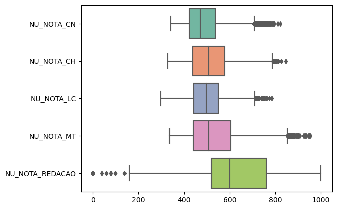

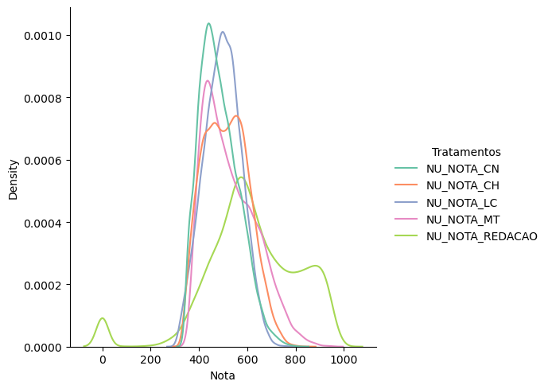

```python
notas = base_trat[['NU_NOTA_CN', 'NU_NOTA_CH', 'NU_NOTA_LC', 'NU_NOTA_MT', 'NU_NOTA_REDACAO']]

notas_temp = notas.melt(id_vars=[], var_name = "Tratamentos", value_name = "Nota")
ax = sns.boxplot(data=notas, orient='h', palette="Set2")
ax = sns.displot(data=notas_temp, x='Nota', hue = 'Tratamentos', palette='Set2', kind='kde')
```

Com base nos gráficos acima notamos que possívelmente há uma pequena diferença entre as áreas de Ciências da Natureza, Ciências Humanas, Linguagem e Matemática e uma diferença mais significativa da nota de Redação para as demais. A fim da confirmação dessa hipótese empregaremos uma Análise de Variância com vistas a identificar se há evidências estatísticas de diferença entre elas e a aplicação de um teste de TUKEY com o objetivo de identificar onde as possíveis diferenças se encontram.

```python
rp.summary_cont(notas)
```

|  | Variable | N | Mean | SD | SE | 95% Conf. | Interval |
| --- | --- | --- | --- | --- | --- | --- | --- |
| 0 | NU_NOTA_CN | 24482.0 | 484.0479 | 79.7956 | 0.5100 | 483.0483 | 485.0475 |
| 1 | NU_NOTA_CH | 24482.0 | 512.4460 | 90.5481 | 0.5787 | 511.3117 | 513.5803 |
| 2 | NU_NOTA_LC | 24482.0 | 497.2370 | 75.6737 | 0.4836 | 496.2891 | 498.1850 |
| 3 | NU_NOTA_MT | 24482.0 | 529.3753 | 107.7126 | 0.6884 | 528.0259 | 530.7246 |
| 4 | NU_NOTA_REDACAO | 24482.0 | 618.1031 | 192.1148 | 1.2278 | 615.6965 | 620.5097 |

```python
fvalue, pvalue = stats.f_oneway(base_trat['NU_NOTA_CN'], base_trat['NU_NOTA_CH'], base_trat['NU_NOTA_LC'], base_trat['NU_NOTA_MT'], base_trat['NU_NOTA_REDACAO'])
print(round(fvalue,4), round(pvalue,4))
```

```
4999.4887 0.0
```

```python
model = ols('Nota ~ Tratamentos', data=notas_temp).fit()
anova_table = sm.stats.anova_lm(model, typ=2)
anova_table
```

|  | sum_sq | df | F | PR(>F) |
| --- | --- | --- | --- | --- |
| Tratamentos | 2.751835e+08 | 4.0 | 4999.488729 | 0.0 |
| Residual | 1.684364e+09 | 122405.0 | NaN | NaN |

Com um p-value de 0.0 pode-se dizer que há diferenças estatísticas entre as médias das notas obtidas. O teste de Tukey abaixo irá identificar onde essas diferenças se encontram.

```python
from bioinfokit.analys import stat
res = stat()
res.tukey_hsd(df=notas_temp, res_var='Nota', xfac_var='Tratamentos', anova_model='Nota ~ C(Tratamentos)')
res.tukey_summary
```

|  | group1 | group2 | Diff | Lower | Upper | q-value | p-value |
| --- | --- | --- | --- | --- | --- | --- | --- |
| 0 | NU_NOTA_CN | NU_NOTA_CH | 28.398043 | 25.505891 | 31.290196 | 37.878559 | 0.001 |
| 1 | NU_NOTA_CN | NU_NOTA_LC | 13.189078 | 10.296925 | 16.081230 | 17.592172 | 0.001 |
| 2 | NU_NOTA_CN | NU_NOTA_MT | 45.327310 | 42.435157 | 48.219462 | 60.459559 | 0.001 |
| 3 | NU_NOTA_CN | NU_NOTA_REDACAO | 134.055155 | 131.163002 | 136.947307 | 178.808659 | 0.001 |
| 4 | NU_NOTA_CH | NU_NOTA_LC | 15.208966 | 12.316813 | 18.101118 | 20.286387 | 0.001 |
| 5 | NU_NOTA_CH | NU_NOTA_MT | 16.929266 | 14.037114 | 19.821419 | 22.581000 | 0.001 |
| 6 | NU_NOTA_CH | NU_NOTA_REDACAO | 105.657111 | 102.764959 | 108.549264 | 140.930100 | 0.001 |
| 7 | NU_NOTA_LC | NU_NOTA_MT | 32.138232 | 29.246080 | 35.030385 | 42.867387 | 0.001 |
| 8 | NU_NOTA_LC | NU_NOTA_REDACAO | 120.866077 | 117.973925 | 123.758230 | 161.216487 | 0.001 |
| 9 | NU_NOTA_MT | NU_NOTA_REDACAO | 88.727845 | 85.835692 | 91.619997 | 118.349100 | 0.001 |

Através da tabela apreende-se que há diferenças estatísticas **muito significativas** pois em todas as comparações os **p-valores** foram inferiores a **1%**. Destacamos as diferenças obtidas entre as notas de Redação e Ciências da Natureza (134 pontos), Redação e Linguagem (120 pontos) e Redação e Ciências Humanas (105 pontos). Note que, embora vislumbrassemos essas diferenças através da inspeção visual dos gráficos, apenas pudemos ter certeza dessas diferenças após a execução de um teste estatístico de hipóteses como o que realizamos. Um ponto importânte a se destacar neste caso é que para a obtenção das notas de Redação não seguiu-se a mesma metodologia que a utilizada para obtenção das demais.

```python
# Altera os campos TP_FAIXA_ETARIA, TP_SEXO, TP_ESTADO_CIVIL, TP_COR_RACA, TP_DEPENDENCIA_ADM_ESC,
# e PONTUACAO deixando-as como uma string mais explicativa.
base_trat['TP_FAIXA_ETARIA'].replace({1:'Menor de 17 anos', 2:'17 anos', 3:'18 anos', 4:'19 anos',
                                      5:'20 anos', 6:'21 anos', 7:'22 anos', 8:'23 anos', 9:'24 anos',
                                      10:'25 anos', 11:'Entre 26 e 30 anos', 12:'Entre 31 e 35 anos',
                                      13:'Entre 36 e 40 anos', 14:'Entre 41 e 45 anos', 15:'Entre 46 e 50 anos',
                                      16:'Entre 51 e 55 anos',17:'Entre 56 e 60 anos', 18:'Entre 61 e 65 anos',
                                      19:'Entre 66 e 70 anos', 20:'Maior de 70 anos'},inplace= True)

base_trat['TP_SEXO'].replace({"F": 'Feminino', "M": 'Masculino'}, inplace= True)

base_trat['TP_ESTADO_CIVIL'].replace({0:'Não informado', 1:'Solteiro(a)',
                                      2:'Casado(a)/Mora com companheiro(a)',
                                      3:'Divorciado(a)/Desquitado(a)/Separado(a)',
                                      4:'Viúvo(a)'}, inplace= True)

base_trat['TP_COR_RACA'].replace({0:'Não declarado', 1:'Branca', 2:'Preta', 3:'Parda',
                                  4:'Amarela', 5:'Indígena', 6:'Não dispõe da informação'}, inplace= True)

base_trat['TP_DEPENDENCIA_ADM_ESC'].replace({1:'Federal', 2:'Estadual', 3:'Municipal', 4:'Privada'}, inplace= True)

base_trat['PONTUACAO'].replace({0:'DE', 1:'C2', 2:'C1', 3:'B1', 4:'B2', 5:'A'}, inplace= True)
```

```python
def sumario_agrupado(nota, var2):
    # Estatística Descritiva das notas separados por var2
    print()
    print('Sumário de ', nota, ' ', 'por ',var2, '.')
    print(rp.summary_cont(base_trat[nota].groupby(base_trat[var2])))
    print()
```

```python
variaveis = ['TP_FAIXA_ETARIA', 'TP_SEXO', 'TP_ESTADO_CIVIL', 'TP_COR_RACA', 'TP_DEPENDENCIA_ADM_ESC', 'PONTUACAO']
notas = ['NU_NOTA_CN', 'NU_NOTA_CH', 'NU_NOTA_LC', 'NU_NOTA_MT', 'NU_NOTA_REDACAO']

for nota in notas:
    for var in variaveis:
        sumario_agrupado(nota, var)
```

```
Sumário de  NU_NOTA_CN   por  TP_FAIXA_ETARIA .


                        N      Mean       SD       SE  95% Conf.  Interval
TP_FAIXA_ETARIA
17 anos             11037  491.6707  81.3148   0.7740   490.1535  493.1878
18 anos             11278  481.6458  78.8600   0.7426   480.1902  483.1014
19 anos              1278  450.9893  66.4732   1.8594   447.3414  454.6372
20 anos               246  446.3667  64.1461   4.0898   438.3110  454.4223
21 anos                58  433.9552  66.1157   8.6814   416.5709  451.3394
22 anos                28  445.2571  69.1353  13.0653   418.4493  472.0650
23 anos                17  456.6529  50.3255  12.2057   430.7779  482.5279
24 anos                10  446.1000  57.7605  18.2655   404.7807  487.4193
25 anos                11  421.0455  38.6735  11.6605   395.0643  447.0266
Entre 26 e 30 anos     47  439.6830  53.2536   7.7678   424.0471  455.3188
Entre 31 e 35 anos     36  442.0917  66.1138  11.0190   419.7220  464.4613
Entre 36 e 40 anos     30  431.9833  51.6811   9.4356   412.6853  451.2814
Entre 41 e 45 anos     14  439.9714  31.7644   8.4894   421.6312  458.3117
Entre 46 e 50 anos     18  421.3167  49.8362  11.7465   396.5337  446.0996
Entre 51 e 55 anos     10  437.8300  47.9322  15.1575   403.5414  472.1186
Entre 56 e 60 anos      2  473.9500  47.0226  33.2500    51.4687  896.4313
Entre 61 e 65 anos      3  546.9333  46.5586  26.8806   431.2754  662.5913
Menor de 17 anos      359  504.1184  74.6521   3.9400   496.3700  511.8668


Sumário de  NU_NOTA_CN   por  TP_SEXO .


               N      Mean       SD      SE  95% Conf.  Interval
TP_SEXO
Feminino   13622  474.9533  75.4269  0.6463   473.6865  476.2200
Masculino  10860  495.4556  83.5741  0.8020   493.8836  497.0276


Sumário de  NU_NOTA_CN   por  TP_ESTADO_CIVIL .


                                             N      Mean        SD       SE  \
TP_ESTADO_CIVIL
Casado(a)/Mora com companheiro(a)          171  451.4053   65.8492   5.0356
```

[output cut: 412 more lines]

```
Municipal               630.2144
Privada                 755.9892


Sumário de  NU_NOTA_REDACAO   por  PONTUACAO .


              N      Mean        SD      SE  95% Conf.  Interval
PONTUACAO
A          1828  784.8578  152.8594  3.5752   777.8458  791.8697
B1         5187  672.4851  175.5443  2.4374   667.7067  677.2634
B2         1761  729.4151  165.7509  3.9498   721.6683  737.1619
C1         5470  615.2322  176.7729  2.3901   610.5466  619.9178
C2         5138  569.9611  175.1261  2.4432   565.1714  574.7507
DE         5098  516.1279  183.3193  2.5675   511.0945  521.1613
```

Para todas as comparações efetuadas anteriormente os valores das médias aparentam ser estatísticamente diferentes. Com vistas a confirmação destas hipóteses procederemos a execução de uma análise de variância comparando as respectivas notas e variáveis comparativas.

```python
compara = ['NU_NOTA_CN ~ TP_FAIXA_ETARIA', 'NU_NOTA_CN ~ TP_SEXO', 'NU_NOTA_CN ~ TP_ESTADO_CIVIL', 'NU_NOTA_CN ~ TP_COR_RACA', 'NU_NOTA_CN ~ TP_DEPENDENCIA_ADM_ESC', 'NU_NOTA_CN ~ PONTUACAO',
        'NU_NOTA_CH ~ TP_FAIXA_ETARIA', 'NU_NOTA_CH ~ TP_SEXO', 'NU_NOTA_CH ~ TP_ESTADO_CIVIL', 'NU_NOTA_CH ~ TP_COR_RACA', 'NU_NOTA_CH ~ TP_DEPENDENCIA_ADM_ESC', 'NU_NOTA_CH ~ PONTUACAO',
        'NU_NOTA_LC ~ TP_FAIXA_ETARIA', 'NU_NOTA_LC ~ TP_SEXO', 'NU_NOTA_LC ~ TP_ESTADO_CIVIL', 'NU_NOTA_LC ~ TP_COR_RACA', 'NU_NOTA_LC ~ TP_DEPENDENCIA_ADM_ESC', 'NU_NOTA_LC ~ PONTUACAO',
        'NU_NOTA_MT ~ TP_FAIXA_ETARIA', 'NU_NOTA_MT ~ TP_SEXO', 'NU_NOTA_MT ~ TP_ESTADO_CIVIL', 'NU_NOTA_MT ~ TP_COR_RACA', 'NU_NOTA_MT ~ TP_DEPENDENCIA_ADM_ESC', 'NU_NOTA_MT ~ PONTUACAO',
        'NU_NOTA_REDACAO ~ TP_FAIXA_ETARIA', 'NU_NOTA_REDACAO ~ TP_SEXO', 'NU_NOTA_REDACAO ~ TP_ESTADO_CIVIL', 'NU_NOTA_REDACAO ~ TP_COR_RACA', 'NU_NOTA_REDACAO ~ TP_DEPENDENCIA_ADM_ESC', 'NU_NOTA_REDACAO ~ PONTUACAO']

def anova(compara):
    model = ols(compara, data=base_trat).fit()
    anova_table = sm.stats.anova_lm(model, typ=2)
    print(anova_table)

for comp in compara:
    print(comp)
    anova(comp)
    print()
    print()
```

```
NU_NOTA_CN ~ TP_FAIXA_ETARIA
                       sum_sq       df         F        PR(>F)
TP_FAIXA_ETARIA  3.224142e+06     17.0  30.39362  7.250815e-98
Residual         1.526548e+08  24464.0       NaN           NaN


NU_NOTA_CN ~ TP_SEXO
                sum_sq       df           F        PR(>F)
TP_SEXO   2.539983e+06      1.0  405.499109  1.856751e-89
Residual  1.533389e+08  24480.0         NaN           NaN


NU_NOTA_CN ~ TP_ESTADO_CIVIL
                       sum_sq       df        F        PR(>F)
TP_ESTADO_CIVIL  2.149273e+05      4.0  8.44893  8.291812e-07
Residual         1.556640e+08  24477.0      NaN           NaN


NU_NOTA_CN ~ TP_COR_RACA
                   sum_sq       df           F         PR(>F)
TP_COR_RACA  7.491968e+06      5.0  247.155751  1.739435e-258
Residual     1.483869e+08  24476.0         NaN            NaN


NU_NOTA_CN ~ TP_DEPENDENCIA_ADM_ESC
                              sum_sq       df            F  PR(>F)
TP_DEPENDENCIA_ADM_ESC  3.184093e+07      3.0  2094.526332     0.0
Residual                1.240380e+08  24478.0          NaN     NaN


NU_NOTA_CN ~ PONTUACAO
                 sum_sq       df            F  PR(>F)
PONTUACAO  2.847676e+07      5.0  1094.168965     0.0
Residual   1.274021e+08  24476.0          NaN     NaN


NU_NOTA_CH ~ TP_FAIXA_ETARIA
                       sum_sq       df          F        PR(>F)
TP_FAIXA_ETARIA  4.094919e+06     17.0  29.970072  2.224370e-96
Residual         1.966238e+08  24464.0        NaN           NaN
```

[output cut: 123 more lines]

```
                   sum_sq       df           F         PR(>F)
TP_COR_RACA  4.407623e+07      5.0  251.040429  1.724076e-262
Residual     8.594709e+08  24476.0         NaN            NaN


NU_NOTA_REDACAO ~ TP_DEPENDENCIA_ADM_ESC
                              sum_sq       df            F  PR(>F)
TP_DEPENDENCIA_ADM_ESC  1.827894e+08      3.0  2069.265826     0.0
Residual                7.207577e+08  24478.0          NaN     NaN


NU_NOTA_REDACAO ~ PONTUACAO
                 sum_sq       df           F  PR(>F)
PONTUACAO  1.529579e+08      5.0  997.562067     0.0
Residual   7.505892e+08  24476.0         NaN     NaN
```

# Resultados e Discussões

voltar ao sumário

Nota-se através do cotejo dos resultados tanto das sumarizações das notas para cada variável estudada e quanto para as Análises de Variâncias que são muito significativas as diferenças entre as médias das categorias. Teceremos considerações para cada uma das variáveis a seguir.

### Faixa Etária

Devido à própria natureza de estudo - avaliação escolar - há de se supor que os jovens - considerando os entre 18 e 25 anos, tivessem melhores resultados que os mais velhos uma vez que é esperado que os mesmos tenham concluído a memos tempo seus estudos no ensino básico. Observamos esse fenômeno em todas as quatro notas e redação. Uma excessão a essa regra se aplicou para o grupo de candidatos entre 61 a 65 anos que em todas as notas se equiparou às faixas inferiores a 17 anos. Ilustraremos esses resultados através do boxplot abaixo.

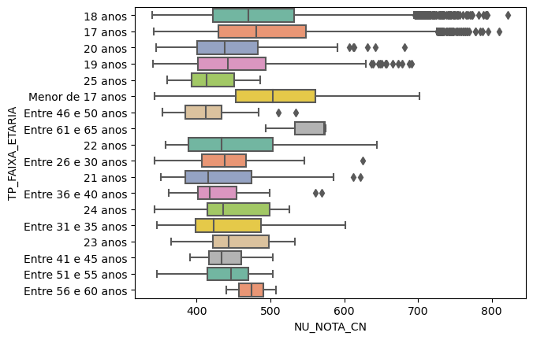

```python
ax = sns.boxplot(data=base_trat, y='TP_FAIXA_ETARIA', x='NU_NOTA_CN', orient='h', palette="Set2")
```

### SEXO

Não imaginamos qualquer razão latente para diferenciação das notas entre homens e mulheres, no entanto embora para todas as notas tenha ocorrido pequenas diferenças em favor do sexo masculino as mesmas se mostraram muito significativas no teste de diferenças de médias. Representamos abaixo a nota obtida em Ciências Humanas.

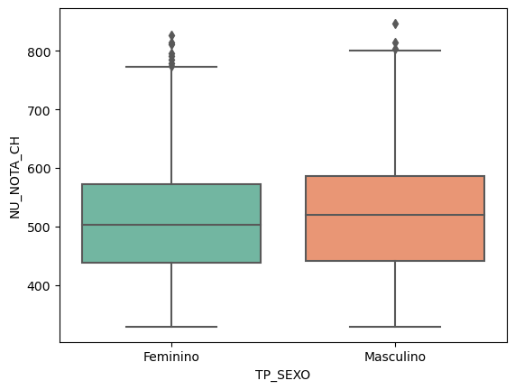

```python
ax = sns.boxplot(data=base_trat, x='TP_SEXO', y='NU_NOTA_CH', orient='v', palette="Set2")
```

### ESTADO CIVIL

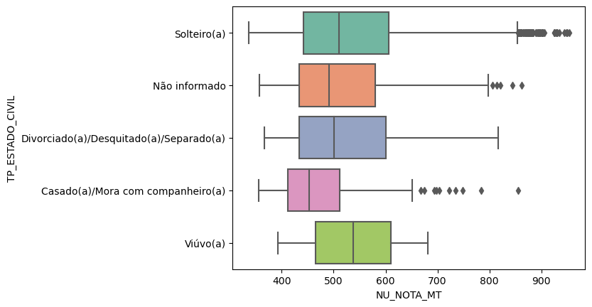

```python
ax = sns.boxplot(data=base_trat, y='TP_ESTADO_CIVIL', x='NU_NOTA_MT', orient='h', palette="Set2")
```

### COR/RACA

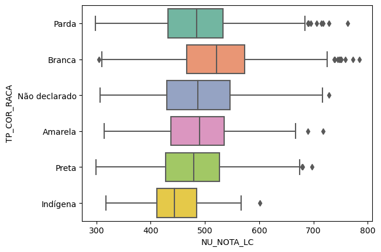

```python
ax = sns.boxplot(data=base_trat, y='TP_COR_RACA', x='NU_NOTA_LC', orient='h', palette="Set2")
```

### DEPENDENCIA ADMINISTRATIVA ESCOLAR

Há muita discussão quanto à qualidade do ensino em nossas redes públicas e privadas. Nota-se que os resultados em todas as áreas foi estatísticamente significativo destacando-se as instituições privadas como tendo obtido as melhores notas inclusive superiores a 500 pontos em quase todas as áreas. Em seguida vemos as instituições federais seguidos das estaduais e municipais. Pensando que a educação é um direito os gestores públicos devem envidar esforços com vistas a melhorias desses resultados. Veja os resultados para a área das Matemáticas.

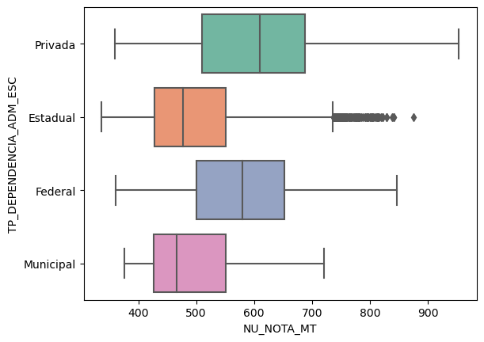

```python
ax = sns.boxplot(data=base_trat, y='TP_DEPENDENCIA_ADM_ESC', x='NU_NOTA_MT', orient='h', palette="Set2")
```

### PONTUAÇÃO

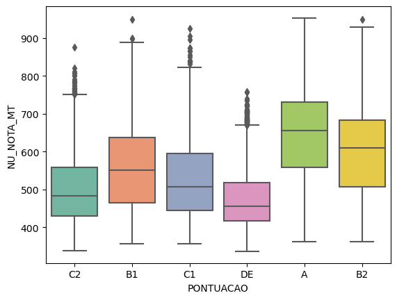

```python
ax = sns.boxplot(data=base_trat, x='PONTUACAO', y='NU_NOTA_MT', orient='v', palette="Set2")
```

# Conclusões e Sugestões

voltar ao sumário

Acreditamos ter apresentado neste trabalho um pequeno exemplo do tipo de estudo que pode ser realizado a partir do cotejo dos dados coletados pela prova do ENEM. Acreditamos também que os gestores educacionais públicos e privados muito tem a ganhar com abordagens como a que realizamos, e que permite aos mesmos redirecionar suas ações gerenciais. Não obstante, temos clara consciência de que o trabalho não se esgota aqui, mesmo considerando o próprio material que utilizamos uma vez que empregamos tão somente uma pequena fração do mesmo. Vislumbramos algumas outras abordagens que poderiam ser usadas e que possibilitaria seu aprofundamento. Dividiremos as abordagens em visões macro e micro educacional.

### Visão Macroeducacional

Além da abordagem realizada aqui, agregando informações de outras fontes, poderia-se estudar o desempenho das diferentes instituições de ensino dos municipios o que permitiria a Secretários da Educação dos mesmos aferir que fatores mais influenciam a atuação dos alunos de suas respectivas redes de ensino.

### Visão Microeducacional

Embora não realizado neste estudo acreditamos que há uma grande oportunidade no aprofundamento das análises das questões das provas pensando na abordagem **Clássica** da Psicometria. Um cotejo detalhado da natureza de cada item com as respectivas respostas dos candidatos segmentados por UF, Tipos de Unidades de Ensino e/ou Escolas permitiria aos respectivos gestores educacionais a descoberta dos GAPs de ensino que possuem.

Não descartamos ainda o emprego de metodologias empregadas no moderna Ciência dos Dados, muito utilizadas na modelagem como Machine Learning e/ou Deep Learning, modelos que poderiam ser usados como preditores das chances de sucesso/insucesso dos candidatos dadas as condições em seus ambientes.

# Referências bibliográticas consultadas

voltar ao sumário

Bacellar, Danilo. Teoria da Resposta ao Item. In: Blog: StatPlace. Disponível em https://statplace.com.br/blog/o-que-e-teoria-de-resposta-ao-item/, em 08/12/2022

Brasil. Instituto Nacional de Estudos e Pesquisas Educacionais Anísio Teixeira. Exame Nacional do Ensino Médio – Enem : procedimentos de análise [recurso eletrônico]. – Brasília, DF : Inep, 2021.

BRASIL. Instituto Nacional de Estudos e Pesquisas Educacionais Anísio Teixeira (Inep). Entenda a sua nota no Enem: guia do participante. Brasília, DF: INEP, 2021.

Massêo, Ana. Entenda a correção realizada pela Teoria de Resposta ao Item. In: Imaginie:Blog. Disponível em https://blog.imaginie.com.br/teoria-de-resposta-ao-item/, em 08/12/2022.

Item Response Theory. In: WIKIPÉDIA: a enciclopédia livre. Wikimedia, 2006 Disponível em https://en.wikipedia.org/wiki/Item_response_theory, em 08/12/2022.